# 551_Case_study

Matthew Stoebe

2024-10-07

#Setup

#EDA

```r
# Read the CSV file
lpga_data <- read.csv("LPGA.csv")

# View the first few rows
head(lpga_data)
```

```
##            Golfer rounds avedist pctfrwy pctgrn aveputt avesand pctsndsv przrnd
## 1     Audra Burks     34   239.2    68.6   60.5   23.91   0.824     39.3   1160
## 2   Nicole Perrot     31   243.0    59.2   53.7   23.06   1.419     38.6    979
## 3 Nicole Castrale     87   245.7    71.5   67.0   24.16   0.425     32.4   6116
## 4      Lisa Strom     38   261.5    62.7   62.1   27.37   0.921     40.0    441
## 5   Giulia Sergas     93   255.9    71.7   65.9   24.16   0.796     36.5   4490
## 6     Siew-Ai Lim     31   239.6    62.7   60.6   21.64   1.710     35.8    272
```

```r
# Check data structure
str(lpga_data)
```

```
## 'data.frame':    100 obs. of  9 variables:
##  $ Golfer  : chr  "Audra Burks" "Nicole Perrot" "Nicole Castrale" "Lisa Strom" ...
##  $ rounds  : int  34 31 87 38 93 31 79 77 93 96 ...
##  $ avedist : num  239 243 246 262 256 ...
##  $ pctfrwy : num  68.6 59.2 71.5 62.7 71.7 62.7 67.5 67 66.9 71.2 ...
##  $ pctgrn  : num  60.5 53.7 67 62.1 65.9 60.6 63 62.1 67.9 63.7 ...
##  $ aveputt : num  23.9 23.1 24.2 27.4 24.2 ...
##  $ avesand : num  0.824 1.419 0.425 0.921 0.796 ...
##  $ pctsndsv: num  39.3 38.6 32.4 40 36.5 35.8 34.5 52.3 32.1 46.4 ...
##  $ przrnd  : int  1160 979 6116 441 4490 272 2383 5335 11831 3889 ...
```

```r
# Convert percentage columns to numeric if they are not already
lpga_data$pctfrwy <- as.numeric(lpga_data$pctfrwy)
lpga_data$pctgrn <- as.numeric(lpga_data$pctgrn)

# Summary of quantitative variables
summary(lpga_data)
```

```
##     Golfer              rounds          avedist         pctfrwy
##  Length:100         Min.   : 28.00   Min.   :224.8   Min.   :50.30
##  Class :character   1st Qu.: 54.00   1st Qu.:241.1   1st Qu.:65.38
##  Mode  :character   Median : 65.50   Median :245.9   Median :68.35
##                     Mean   : 67.28   Mean   :246.9   Mean   :67.68
##                     3rd Qu.: 83.00   3rd Qu.:253.0   3rd Qu.:71.22
##                     Max.   :102.00   Max.   :268.5   Max.   :78.80
##      pctgrn         aveputt         avesand          pctsndsv
##  Min.   :53.70   Min.   :21.22   Min.   :0.3660   Min.   :18.90
##  1st Qu.:60.60   1st Qu.:24.04   1st Qu.:0.7020   1st Qu.:32.25
##  Median :63.00   Median :25.43   Median :0.8275   Median :37.15
##  Mean   :62.96   Mean   :25.62   Mean   :0.8521   Mean   :37.89
##  3rd Qu.:65.55   3rd Qu.:27.18   3rd Qu.:0.9417   3rd Qu.:42.67
##  Max.   :70.40   Max.   :30.98   Max.   :1.7100   Max.   :60.00
##      przrnd
##  Min.   :  241
##  1st Qu.: 1500
##  Median : 2064
##  Mean   : 3901
##  3rd Qu.: 5490
##  Max.   :18991
```

```r
# Detailed descriptive statistics
library(psych)
describe(lpga_data[, sapply(lpga_data, is.numeric)])
```

```
##          vars   n    mean      sd  median trimmed     mad    min      max
## rounds      1 100   67.28   18.80   65.50   67.42   18.53  28.00   102.00
## avedist     2 100  246.89    8.64  245.90  246.67    7.71 224.80   268.50
## pctfrwy     3 100   67.68    5.29   68.35   67.98    4.37  50.30    78.80
## pctgrn      4 100   62.96    3.48   63.00   63.09    3.63  53.70    70.40
## aveputt     5 100   25.62    2.21   25.43   25.59    2.32  21.22    30.98
## avesand     6 100    0.85    0.24    0.83    0.83    0.18   0.37     1.71
## pctsndsv    7 100   37.89    8.19   37.15   37.63    7.86  18.90    60.00
## przrnd      8 100 3900.82 3879.98 2064.50 3182.54 1591.57 241.00 18991.00
##             range  skew kurtosis     se
## rounds      74.00  0.03    -0.93   1.88
## avedist     43.70  0.20     0.09   0.86
## pctfrwy     28.50 -0.62     0.74   0.53
## pctgrn      16.70 -0.31    -0.29   0.35
## aveputt      9.76  0.18    -0.59   0.22
## avesand      1.34  1.07     2.21   0.02
## pctsndsv    41.10  0.28    -0.21   0.82
## przrnd   18750.00  1.66     2.40 388.00
```

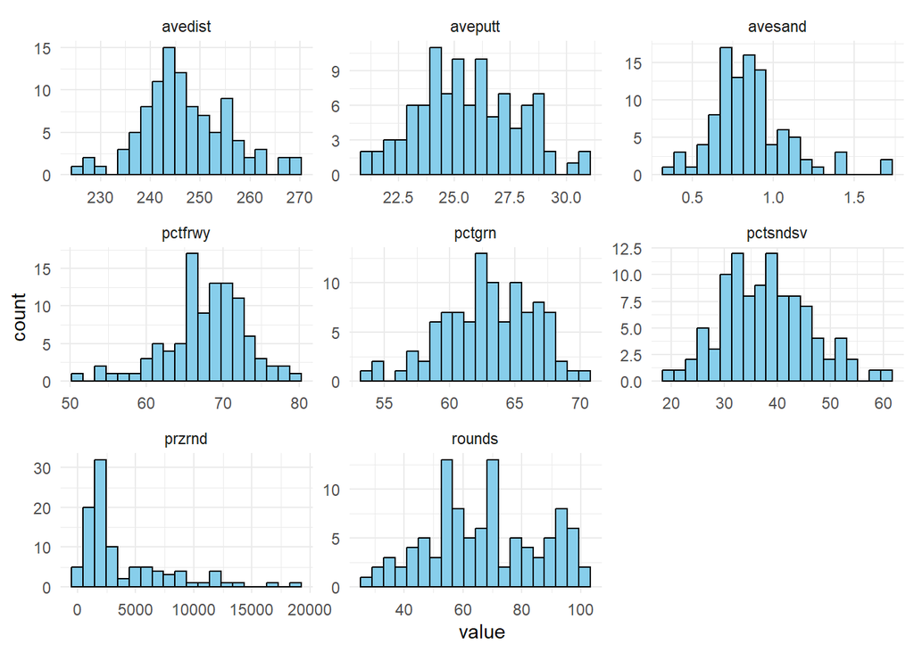

```r
# Histogram for each quantitative variable
lpga_data %>%
  select(-Golfer) %>%
  gather(key = "variable", value = "value") %>%
  ggplot(aes(x = value)) +
  geom_histogram(bins = 20, fill = "skyblue", color = "black") +
  facet_wrap(~ variable, scales = "free") +
  theme_minimal()
```

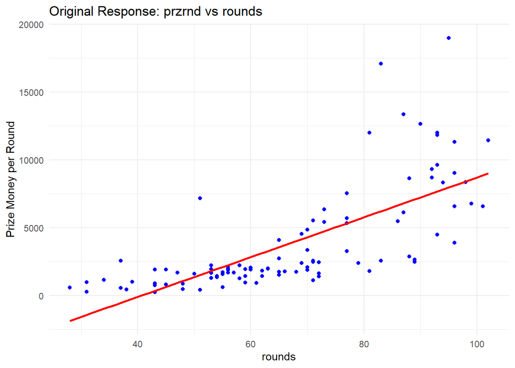

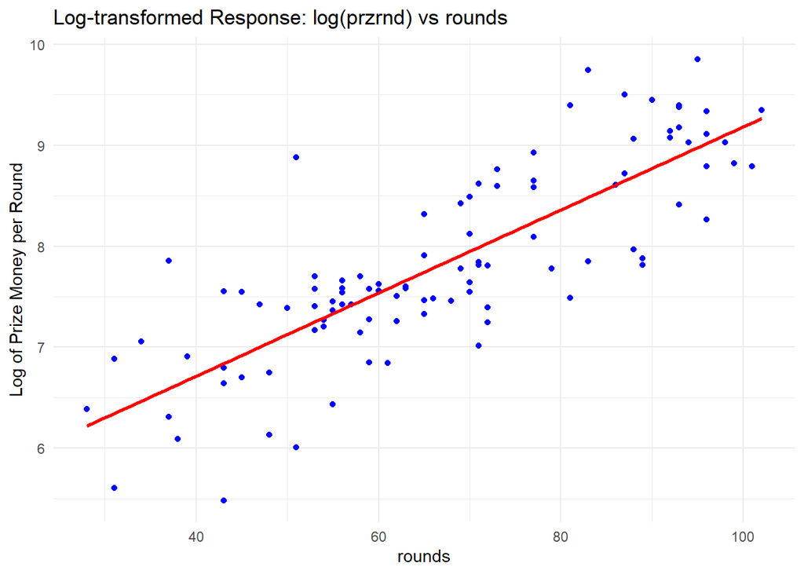

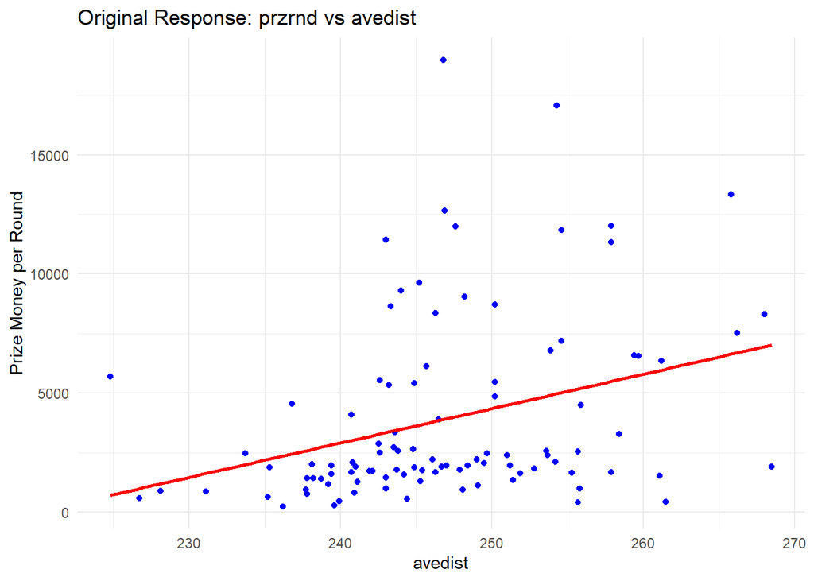

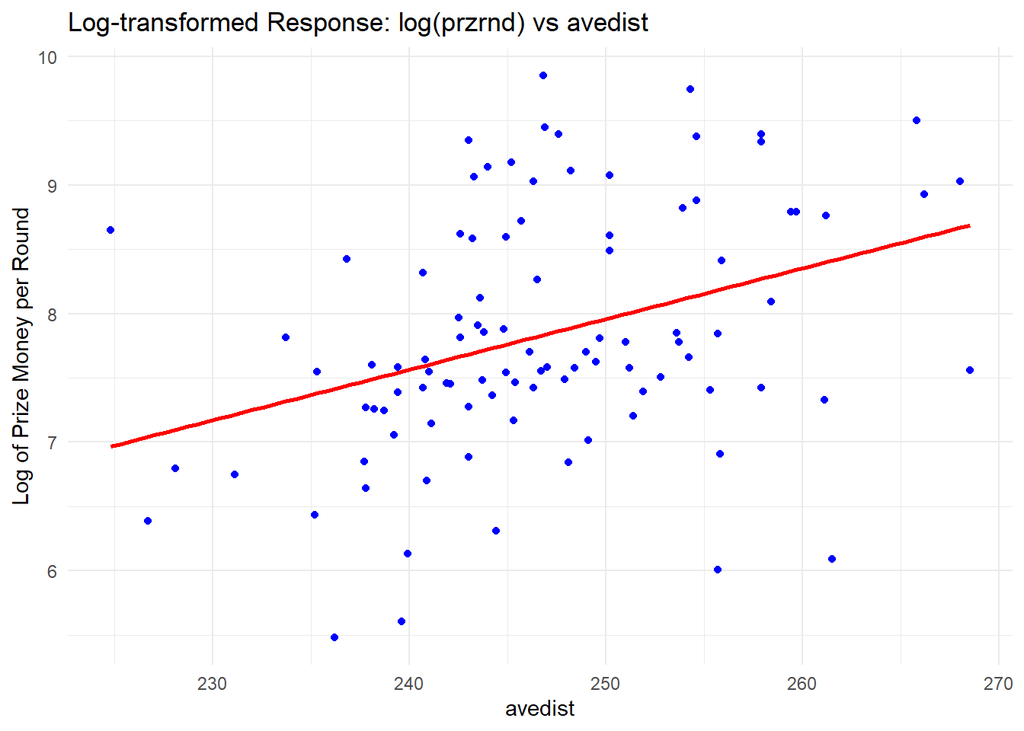

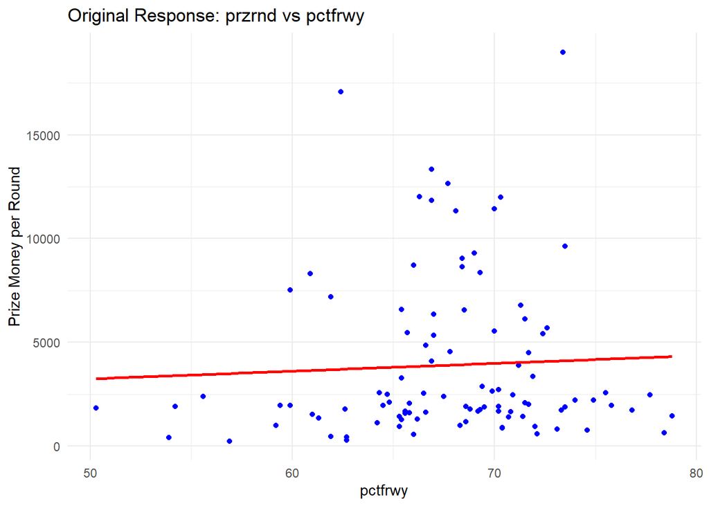

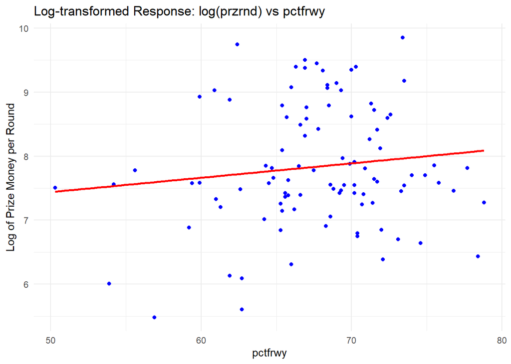

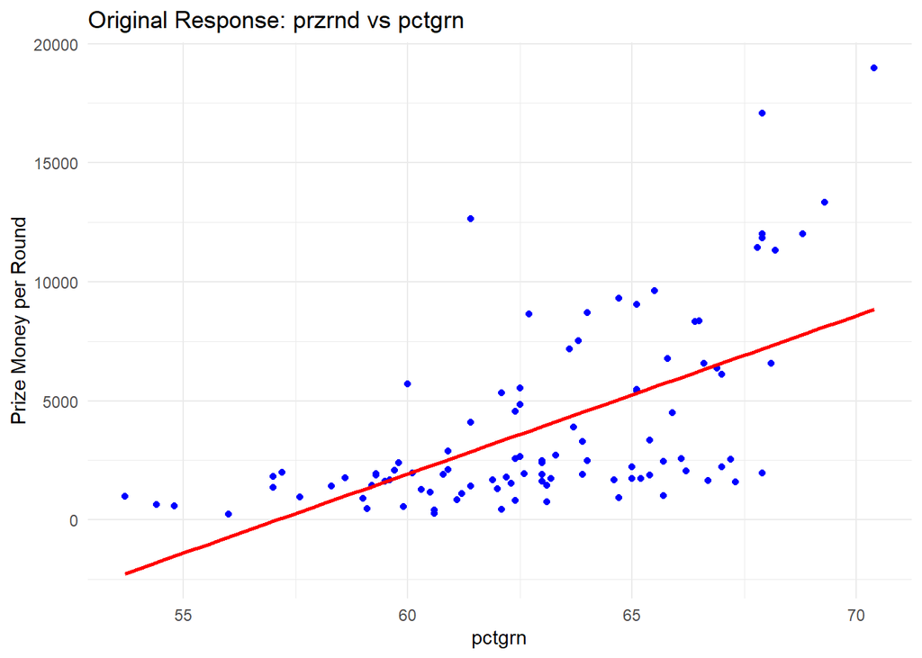

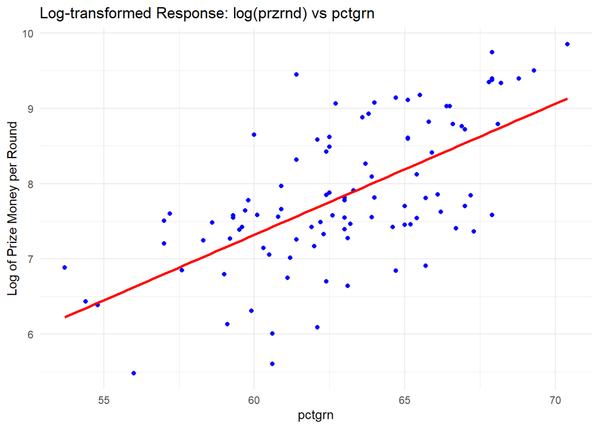

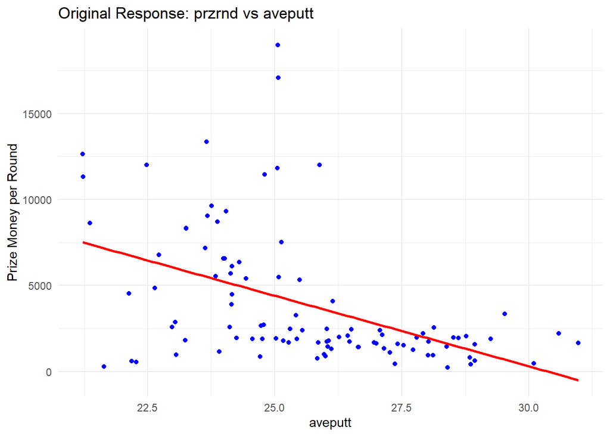

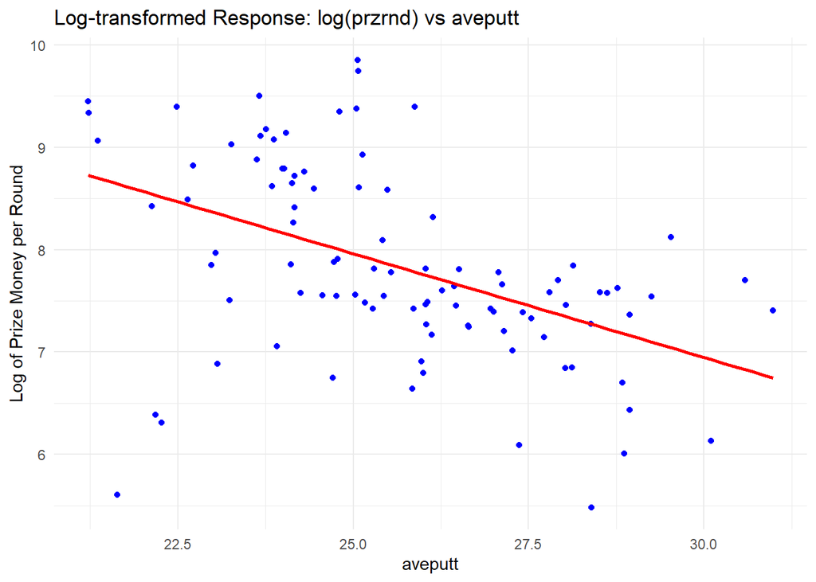

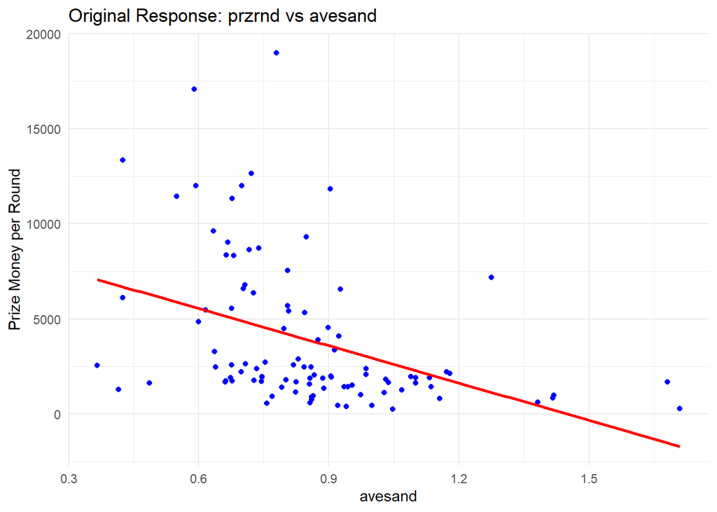

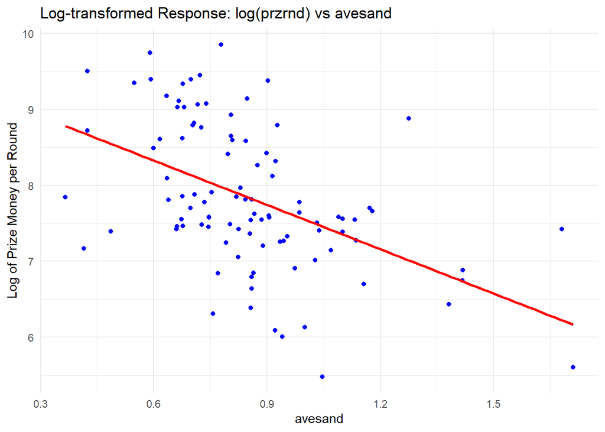

[2 more figures not shown]

```r
predictors <- names(lpga_data)[!(names(lpga_data) %in% c("Golfer", "przrnd"))]

for (var in predictors) {

  # Plot for original response (przrnd)
  p1 <- ggplot(lpga_data, aes(x = .data[[var]], y = przrnd)) +
    geom_point(color = "blue") +
    geom_smooth(method = "lm", se = FALSE, color = "red") +
    labs(title = paste("Original Response: przrnd vs", var), x = var, y = "Prize Money per Round") +
    theme_minimal()

  print(p1)

  # Plot for log-transformed response (log(przrnd))
  p2 <- ggplot(lpga_data, aes(x = .data[[var]], y = log(przrnd))) +
    geom_point(color = "blue") +
    geom_smooth(method = "lm", se = FALSE, color = "red") +
    labs(title = paste("Log-transformed Response: log(przrnd) vs", var), x = var, y = "Log of Prize Money per Round") +
    theme_minimal()

  print(p2)
}
```

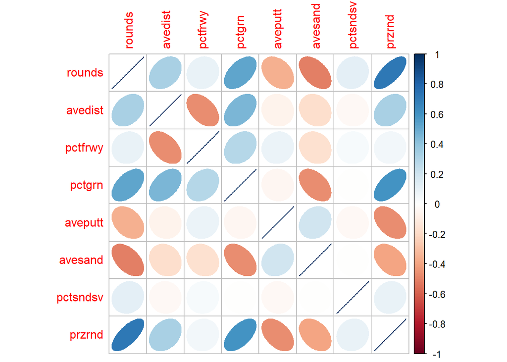

```r
# Correlation matrix of quantitative variables
numeric_vars <- lpga_data %>% select(-Golfer)
cor_matrix <- cor(numeric_vars)

corrplot(cor_matrix, method = "ellipse")
```

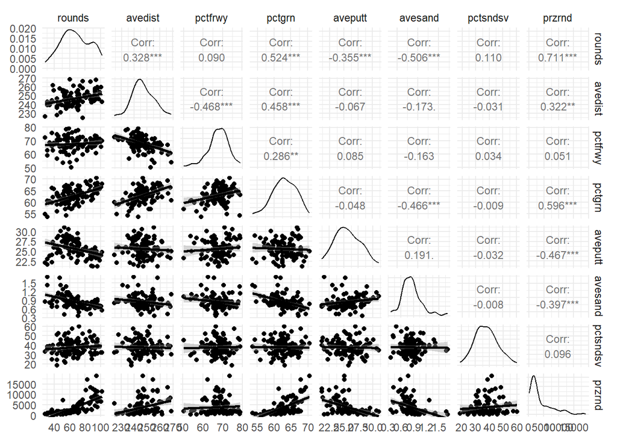

```r
numeric_data <- lpga_data %>% select(-Golfer)
ggpairs(numeric_data,
        lower = list(continuous = "smooth"),
        upper = list(continuous = wrap("cor", size = 3)),
        diag = list(continuous = "densityDiag")) +
  theme_minimal()
```

#Basic Model

```r
# Fit a multiple linear regression model with all predictors
initial_model <- lm(przrnd ~ . - Golfer, data = lpga_data)

# Summary of the model
summary(initial_model)
```

```
##
## Call:
## lm(formula = przrnd ~ . - Golfer, data = lpga_data)
##
## Residuals:
##     Min      1Q  Median      3Q     Max
## -3883.7 -1523.6  -157.8  1023.6  8964.7
##
## Coefficients:
##             Estimate Std. Error t value Pr(>|t|)
## (Intercept) -3901.01   11092.22  -0.352    0.726
## rounds         88.73      16.94   5.237 1.03e-06 ***
## avedist       -51.83      43.17  -1.201    0.233
## pctfrwy      -107.03      65.20  -1.642    0.104
## pctgrn        533.30     108.17   4.930 3.63e-06 ***
## aveputt      -520.00     115.85  -4.489 2.07e-05 ***
## avesand       932.95    1202.71   0.776    0.440
## pctsndsv       21.62      28.84   0.750    0.455
## ---
## Signif. codes:  0 '***' 0.001 '**' 0.01 '*' 0.05 '.' 0.1 ' ' 1
##
## Residual standard error: 2325 on 92 degrees of freedom
## Multiple R-squared:  0.6664, Adjusted R-squared:  0.6411
## F-statistic: 26.26 on 7 and 92 DF,  p-value: < 2.2e-16
```

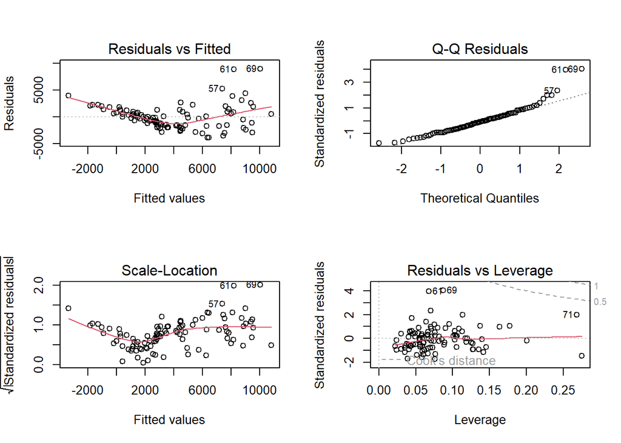

```r
# Plot residuals to check assumptions
par(mfrow = c(2, 2))
plot(initial_model)
```

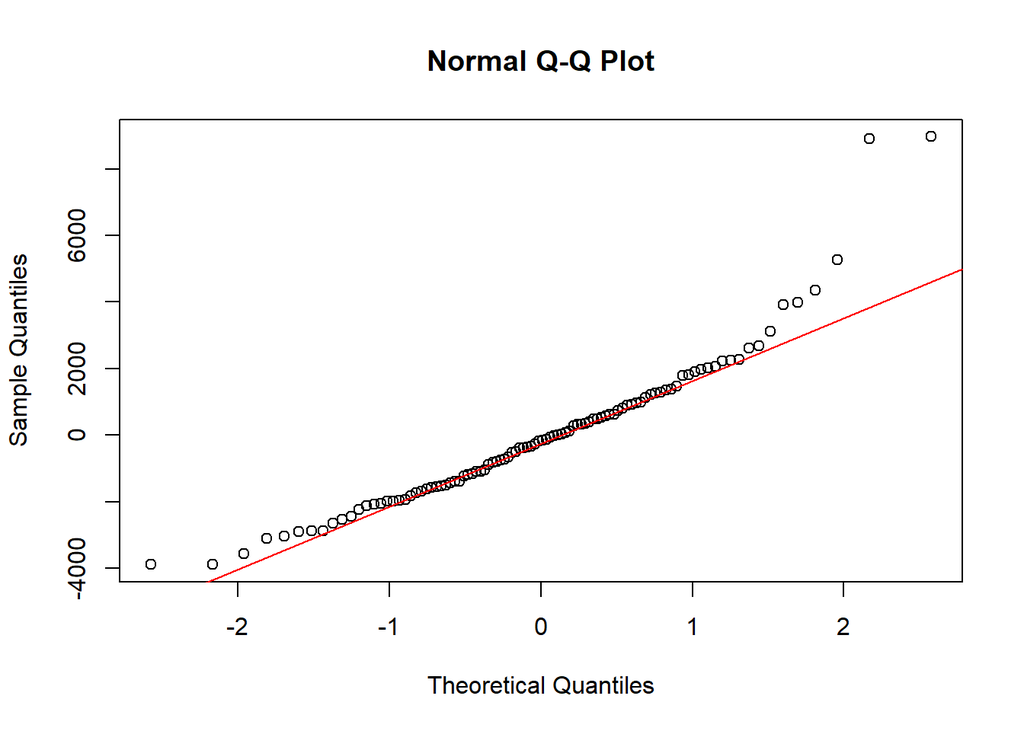

```r
par(mfrow = c(1, 1))  # Reset plotting area

# Q-Q plot
qqnorm(residuals(initial_model))
qqline(residuals(initial_model), col = "red")
```

#Log Transform on Response

```r
log_response <- lm(log(przrnd) ~ . - Golfer, data = lpga_data)

# Summary of the model
summary(log_response)
```

```
##
## Call:
## lm(formula = log(przrnd) ~ . - Golfer, data = lpga_data)
##
## Residuals:
##      Min       1Q   Median       3Q      Max
## -1.44584 -0.30000  0.03416  0.28401  1.18583
##
## Coefficients:
##              Estimate Std. Error t value Pr(>|t|)
## (Intercept)  2.340504   2.182177   1.073    0.286
## rounds       0.026872   0.003333   8.062 2.68e-12 ***
## avedist      0.002221   0.008493   0.262    0.794
## pctfrwy      0.002132   0.012828   0.166    0.868
## pctgrn       0.090784   0.021281   4.266 4.82e-05 ***
## aveputt     -0.113570   0.022791  -4.983 2.92e-06 ***
## avesand     -0.009903   0.236609  -0.042    0.967
## pctsndsv     0.005176   0.005674   0.912    0.364
## ---
## Signif. codes:  0 '***' 0.001 '**' 0.01 '*' 0.05 '.' 0.1 ' ' 1
##
## Residual standard error: 0.4573 on 92 degrees of freedom
## Multiple R-squared:  0.7844, Adjusted R-squared:  0.768
## F-statistic: 47.83 on 7 and 92 DF,  p-value: < 2.2e-16
```

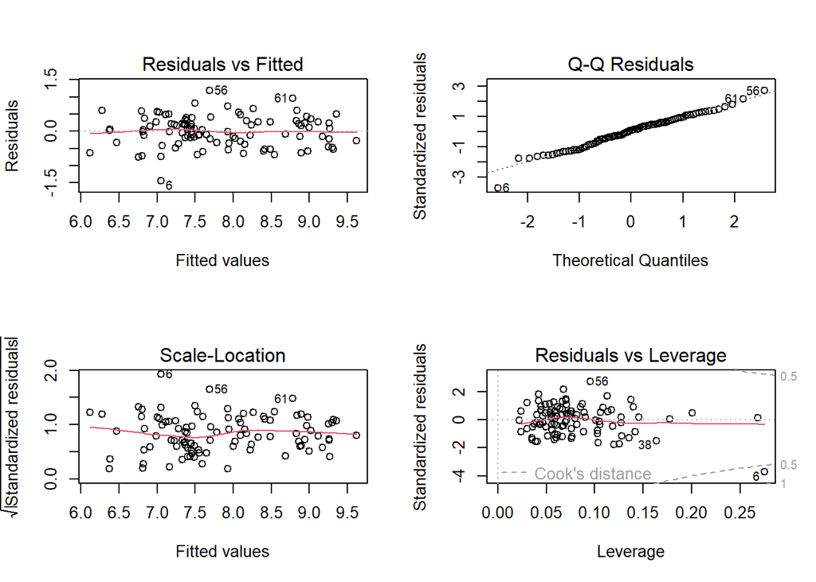

```r
# Plot residuals to check assumptions
par(mfrow = c(2, 2))
plot(log_response)
```

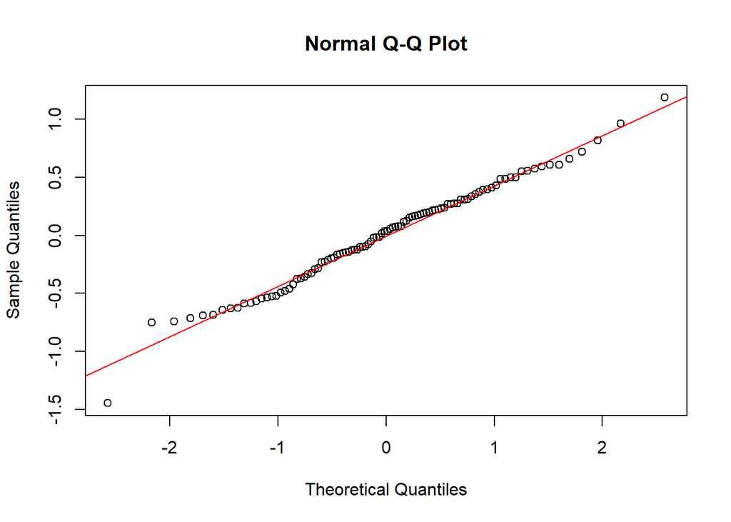

```r
par(mfrow = c(1, 1))  # Reset plotting area

# Q-Q plot
qqnorm(residuals(log_response))
qqline(residuals(log_response), col = "red")
```

#Reduced Feature Set

```r
# Fit a linear model with selected predictors
model_reduced <- lm(log(przrnd) ~ rounds + pctgrn + aveputt, data = lpga_data)

# Check the model summary
summary(model_reduced)
```

```
##
## Call:
## lm(formula = log(przrnd) ~ rounds + pctgrn + aveputt, data = lpga_data)
##
## Residuals:
##      Min       1Q   Median       3Q      Max
## -1.46489 -0.29033  0.03662  0.28986  1.20591
##
## Coefficients:
##              Estimate Std. Error t value Pr(>|t|)
## (Intercept)  3.027677   0.999630   3.029  0.00315 **
## rounds       0.027392   0.003063   8.944 2.76e-14 ***
## pctgrn       0.092986   0.015475   6.009 3.35e-08 ***
## aveputt     -0.112803   0.022237  -5.073 1.91e-06 ***
## ---
## Signif. codes:  0 '***' 0.001 '**' 0.01 '*' 0.05 '.' 0.1 ' ' 1
##
## Residual standard error: 0.4498 on 96 degrees of freedom
## Multiple R-squared:  0.7824, Adjusted R-squared:  0.7756
## F-statistic:   115 on 3 and 96 DF,  p-value: < 2.2e-16
```

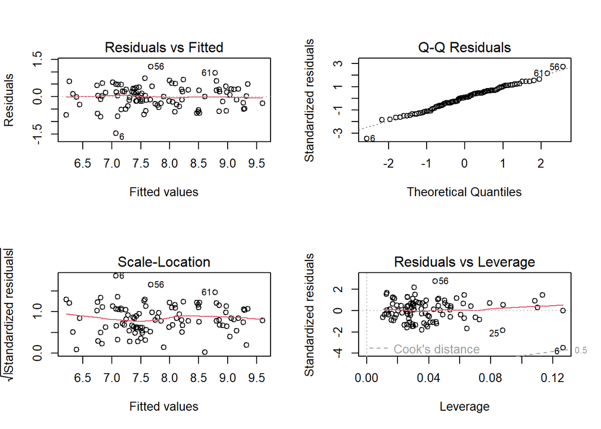

```r
# Diagnostic plots to evaluate the reduced model fit
par(mfrow = c(2, 2))
plot(model_reduced)
```

#Initial Model Comparison

```r
# Also, display the adjusted R-squared for comparison
initial_adj_r2 <- summary(initial_model)$adj.r.squared
log_response_adj_r2 <- summary(log_response)$adj.r.squared
reduced_adj_r2 <- summary(model_reduced)$adj.r.squared

cat("Initial Model Adjusted R-squared:", initial_adj_r2, "\n")
```

```
## Initial Model Adjusted R-squared: 0.6410586
```

```r
cat("Log-Transformed Model Adjusted R-squared:", log_response_adj_r2, "\n")
```

```
## Log-Transformed Model Adjusted R-squared: 0.7680385
```

```r
cat("Reduced Model Adjusted R-squared:", reduced_adj_r2, "\n")
```

```
## Reduced Model Adjusted R-squared: 0.7755512
```

# Standardize features

```r
# Load necessary libraries
library(tidyverse)

# Read the CSV file
lpga_data <- read.csv("LPGA.csv")

# Remove 'Golfer' and 'przrnd' from predictors, as 'Golfer' is categorical and 'przrnd' is the target
predictors <- names(lpga_data)[!(names(lpga_data) %in% c("Golfer", "przrnd"))]

# Standardize the predictor variables
lpga_data_standardized <- lpga_data %>%
  mutate(across(all_of(predictors), ~ scale(.) %>% as.vector))

# Fit a linear model to predict log(przrnd) using standardized inputs
model_standardized <- lm(log(przrnd) ~ . - Golfer, data = lpga_data_standardized)

# Summary of the standardized model
summary(model_standardized)
```

```
##
## Call:
## lm(formula = log(przrnd) ~ . - Golfer, data = lpga_data_standardized)
##
## Residuals:
##      Min       1Q   Median       3Q      Max
## -1.44584 -0.30000  0.03416  0.28401  1.18583
##
## Coefficients:
##              Estimate Std. Error t value Pr(>|t|)
## (Intercept)  7.835841   0.045731 171.346  < 2e-16 ***
## rounds       0.505115   0.062654   8.062 2.68e-12 ***
## avedist      0.019200   0.073409   0.262    0.794
## pctfrwy      0.011284   0.067886   0.166    0.868
## pctgrn       0.316098   0.074098   4.266 4.82e-05 ***
## aveputt     -0.250784   0.050326  -4.983 2.92e-06 ***
## avesand     -0.002337   0.055841  -0.042    0.967
## pctsndsv     0.042416   0.046497   0.912    0.364
## ---
## Signif. codes:  0 '***' 0.001 '**' 0.01 '*' 0.05 '.' 0.1 ' ' 1
##
## Residual standard error: 0.4573 on 92 degrees of freedom
## Multiple R-squared:  0.7844, Adjusted R-squared:  0.768
## F-statistic: 47.83 on 7 and 92 DF,  p-value: < 2.2e-16
```

```r
# Use the model to predict log earnings (log(przrnd))
lpga_data_standardized$log_przrnd_pred <- predict(model_standardized, newdata = lpga_data_standardized)

# View the first few rows of the data with predictions
head(lpga_data_standardized)
```

```
##            Golfer    rounds    avedist    pctfrwy     pctgrn    aveputt
## 1     Audra Burks -1.770476 -0.8900350  0.1730848 -0.7076622 -0.7723108
## 2   Nicole Perrot -1.930074 -0.4503973 -1.6031129 -2.6606260 -1.1572435
## 3 Nicole Castrale  1.049092 -0.1380231  0.7210607  1.1591415 -0.6590953
## 4      Lisa Strom -1.557678  1.6899443 -0.9417627 -0.2481413  0.7945916
## 5   Giulia Sergas  1.368288  1.0420571  0.7588521  0.8432209 -0.6590953
## 6     Siew-Ai Lim -1.930074 -0.8437574 -0.9417627 -0.6789421 -1.8003075
##      avesand    pctsndsv przrnd log_przrnd_pred
## 1 -0.1192760  0.17157768   1160        6.903959
## 2  2.4018321  0.08615494    979        6.281433
## 3 -1.8099014 -0.67044650   6116        8.878725
## 4  0.2917282  0.25700043    441        6.803365
## 5 -0.2379163 -0.17011329   4490        8.980726
## 6  3.6348447 -0.25553604    272        7.051644
```

# Beta Plots

```r
library("rprojroot")
library("rstantools")
library("rstanarm")
```

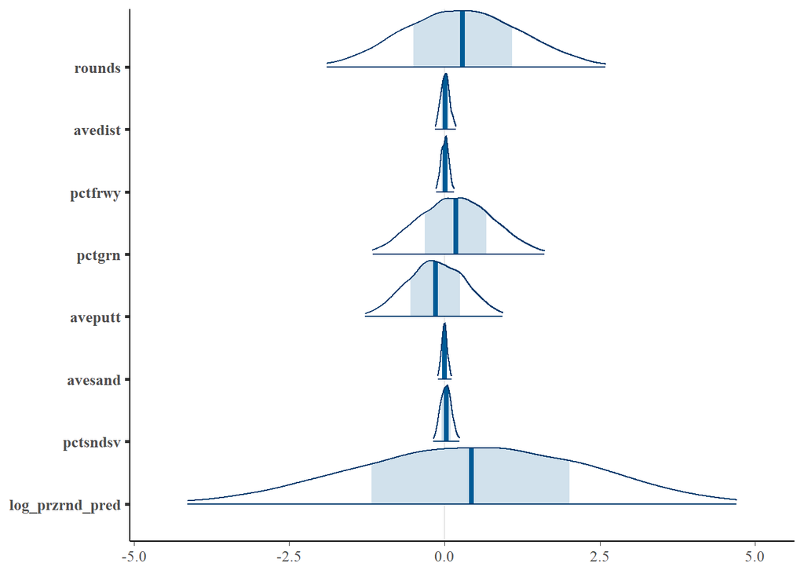

```r
library("loo")
library("ggplot2")
library("bayesplot")
# Fit the model using stan_glm
fit1 <- stan_glm(log(przrnd) ~ . - Golfer, data = lpga_data_standardized, refresh = 0)

# Plot the posterior distributions of the coefficients
p1 <- mcmc_areas(as.matrix(fit1), pars = vars(-'(Intercept)', -sigma),
                 prob_outer = 0.95, area_method = "scaled height")# +
#  xlim(c(-1.2, 0.8))

# Reverse the y-axis labels to match order of parameters
p1 <- p1 + scale_y_discrete(limits = rev(levels(p1$data$parameter)))
# Show the plot
p1
```

#Lasso Feature Selection

```r
library(glmnet)
```

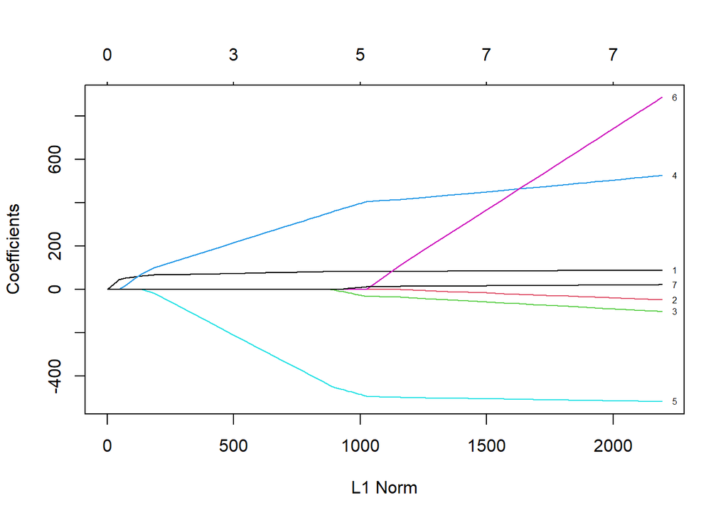

```r
# Fit to all of the predictors in the model (exclude names)
predictors <- c("rounds", "avedist", "pctfrwy", "pctgrn", "aveputt", "avesand", "pctsndsv")
response <- c("przrnd")
fit_lasso <- glmnet(lpga_data[,predictors], lpga_data[,response])
plot(fit_lasso, alpha = 0, label=TRUE) # Default
```

```r
# Table for predictors by number
data.frame(1:length(predictors), predictors)
```

```
##   X1.length.predictors. predictors
## 1                     1     rounds
## 2                     2    avedist
## 3                     3    pctfrwy
## 4                     4     pctgrn
## 5                     5    aveputt
## 6                     6    avesand
## 7                     7   pctsndsv
```

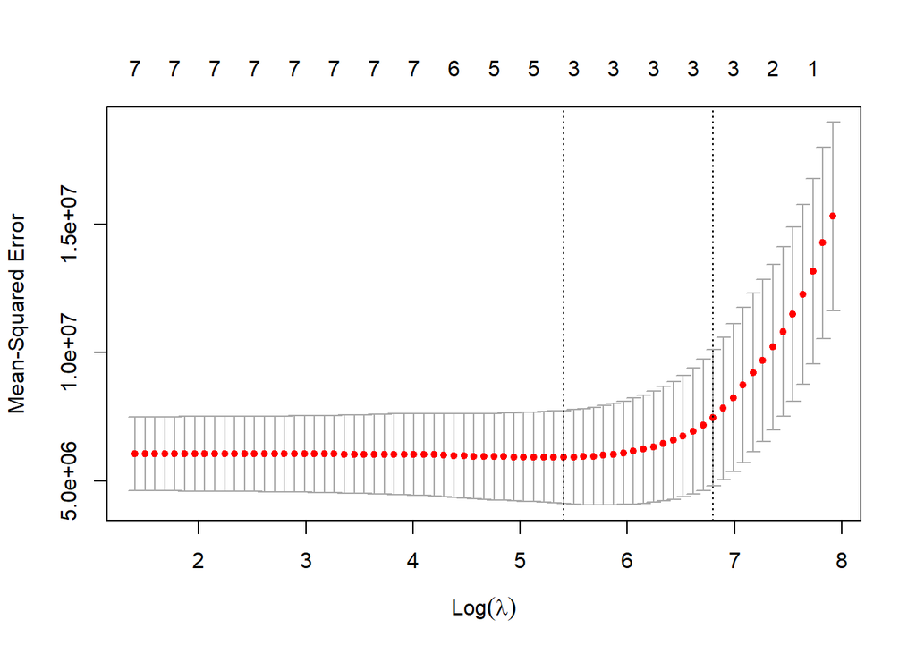

```r
# Fit the Lasso regression model with cross-validation
cv_lasso <- cv.glmnet(as.matrix(lpga_data[,predictors]), lpga_data[,response], alpha = 1)

# Plot the cross-validation curve to show optimal lambda
plot(cv_lasso)
```

```r
# Best lambda from cross-validation
best_lambda <- cv_lasso$lambda.min
cat("Best Lambda: ", best_lambda, "\n")
```

```
## Best Lambda:  222.5746
```

```r
pred_train <- predict(cv_lasso, s = best_lambda, newx = as.matrix(lpga_data[,predictors]))

# Calculate evaluation metrics
mse_train <- mean((lpga_data[,response] - pred_train)^2)
r2_train <- 1 - sum((lpga_data[,response] - pred_train)^2) / sum((lpga_data[,response] - mean(lpga_data[,response]))^2)

cat("Mean Squared Error (Train): ", mse_train, "\n")
```

```
## Mean Squared Error (Train):  5276622
```

```r
cat("R-squared (Train): ", r2_train, "\n")
```

```
## R-squared (Train):  0.6459514
```

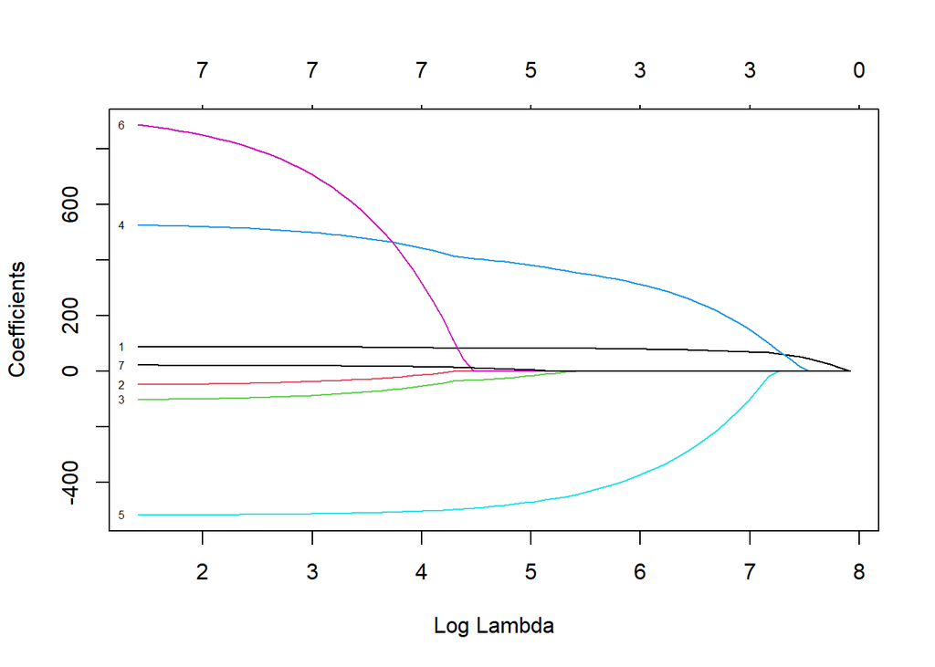

```r
# Plot the coefficient path as lambda varies
plot(cv_lasso$glmnet.fit, xvar = "lambda", label = TRUE)
```

```r
summary(cv_lasso)
```

```
##            Length Class  Mode
## lambda     71     -none- numeric
## cvm        71     -none- numeric
## cvsd       71     -none- numeric
## cvup       71     -none- numeric
## cvlo       71     -none- numeric
## nzero      71     -none- numeric
## call        4     -none- call
## name        1     -none- character
## glmnet.fit 12     elnet  list
## lambda.min  1     -none- numeric
## lambda.1se  1     -none- numeric
## index       2     -none- numeric
```

#Horseshoe Feature Selection

```r
predictors <- c("rounds", "avedist", "pctfrwy", "pctgrn", "aveputt", "avesand", "pctsndsv")
response <- c("przrnd")
lpga_data_cleaned <- lpga_data[,c(predictors, response)]

p <- length(predictors)
n <- nrow(lpga_data)
p0 <- 5
slab_scale <- sqrt(0.3/p0)*sd(lpga_data_cleaned$przrnd)
global_scale <- (p0/(p-p0))/sqrt(n)
fit_horseshoe <- stan_glm(przrnd ~ ., data = lpga_data_cleaned, refresh=0, prior = hs(global_scale=global_scale, slab_scale=slab_scale))
```

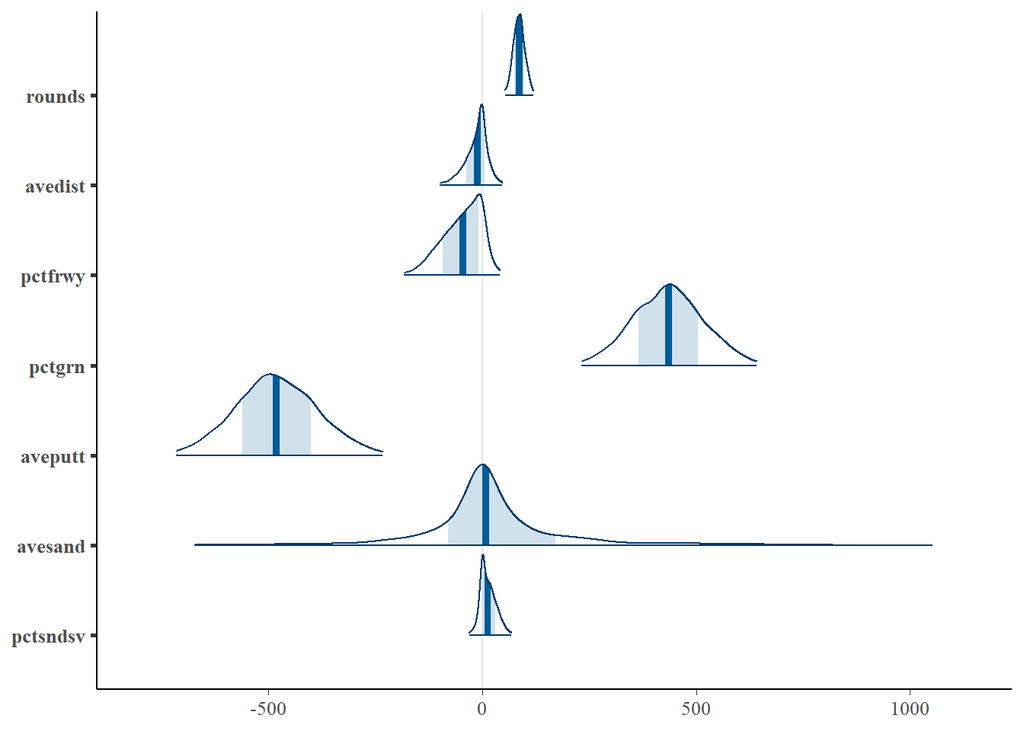

```r
# Plot
library(ggplot2)
p0 <- mcmc_areas(as.matrix(fit_horseshoe), pars=vars(-'(Intercept)', -sigma), prob_outer=0.95, area_method="scaled height")
p0 <- p0 + scale_y_discrete(limits = rev(levels(p0$data$parameter)))
p0
```

#LOO Comparison

```r
library("rstanarm")
library("loo")

# Fit the initial model using stan_glm
fit_initial_stan <- stan_glm(przrnd ~ . - Golfer, data = lpga_data_standardized, refresh = 0)

# Fit the log-transformed model using stan_glm
fit_log_response_stan <- stan_glm(log(przrnd) ~ . - Golfer, data = lpga_data_standardized, refresh = 0)

# Fit the reduced model using stan_glm
fit_reduced_stan <- stan_glm(log(przrnd) ~ rounds + pctgrn + aveputt, data = lpga_data_standardized, refresh = 0)


# Compute LOO for each model
loo_log_response <- loo(fit_log_response_stan)
loo_reduced <- loo(fit_reduced_stan)

# Compare models using loo_compare
loo_comparison <- loo_compare(loo_log_response, loo_reduced)

# Display the LOO comparison results
print(loo_comparison)
```

```
##                       elpd_diff se_diff
## fit_reduced_stan       0.0       0.0
## fit_log_response_stan -4.6       1.3
```

#Full Evaluation

```r
# Step 1: Fit the reduced model using the log-transformed response
fit_reduced_stan_log <- stan_glm(log(przrnd) ~ rounds + pctgrn + aveputt, data = lpga_data, refresh = 0)

# Step 2: Extract LOO Information for the reduced model
loo_reduced_log <- loo(fit_reduced_stan_log)

# Print the LOO results for the reduced model
print(loo_reduced_log)
```

```
##
## Computed from 4000 by 100 log-likelihood matrix.
##
##          Estimate   SE
## elpd_loo    -65.9  8.3
## p_loo         6.1  2.0
## looic       131.9 16.7
## ------
## MCSE of elpd_loo is 0.1.
## MCSE and ESS estimates assume MCMC draws (r_eff in [0.5, 1.7]).
##
## All Pareto k estimates are good (k < 0.7).
## See help('pareto-k-diagnostic') for details.
```

```r
# Step 3: Calculate WAIC for the reduced model
waic_reduced_log <- waic(fit_reduced_stan_log)
# Print the WAIC results for the reduced model
print(waic_reduced_log)
```

```
##
## Computed from 4000 by 100 log-likelihood matrix.
##
##           Estimate   SE
## elpd_waic    -65.9  8.3
## p_waic         6.1  2.0
## waic         131.8 16.7
##
## 2 (2.0%) p_waic estimates greater than 0.4. We recommend trying loo instead.
```

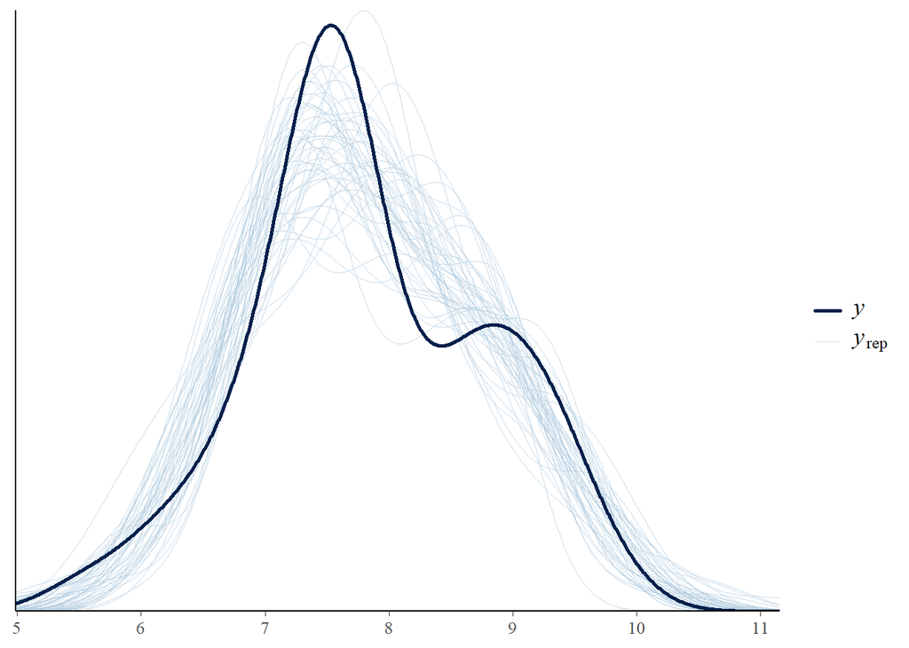

```r
# Step 4: Posterior Predictive Checks
pp_check(fit_reduced_stan_log)
```

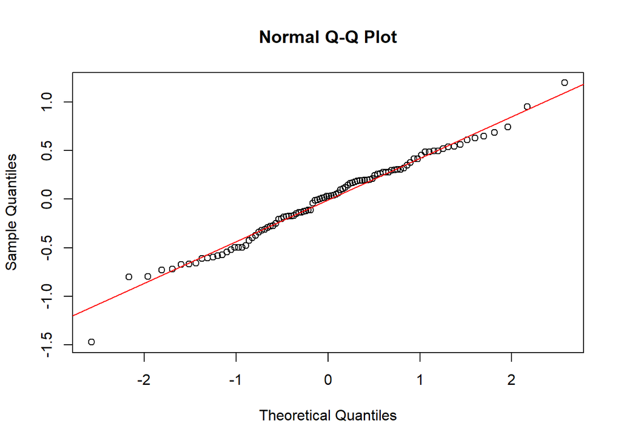

```r
# Step 5: Residual Diagnostics
# Extract residuals
residuals_reduced <- residuals(fit_reduced_stan_log)

# Q-Q plot of residuals
qqnorm(residuals_reduced)
qqline(residuals_reduced, col = "red")
```

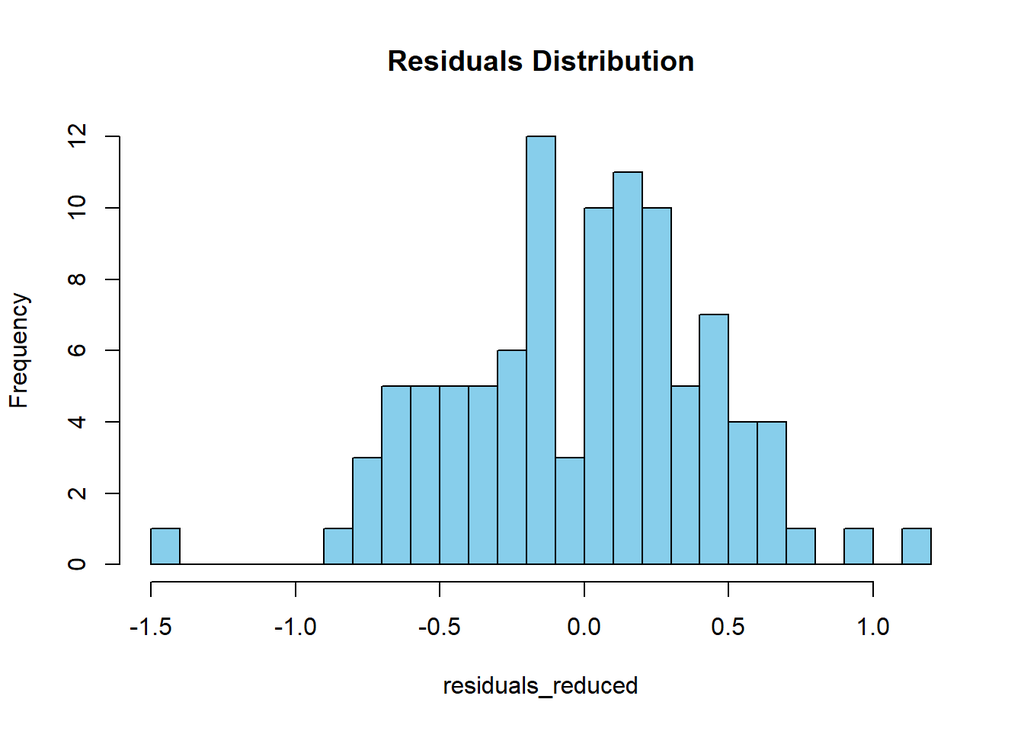

```r
# Histogram of residuals
hist(residuals_reduced, breaks = 20, col = "skyblue", main = "Residuals Distribution")
```

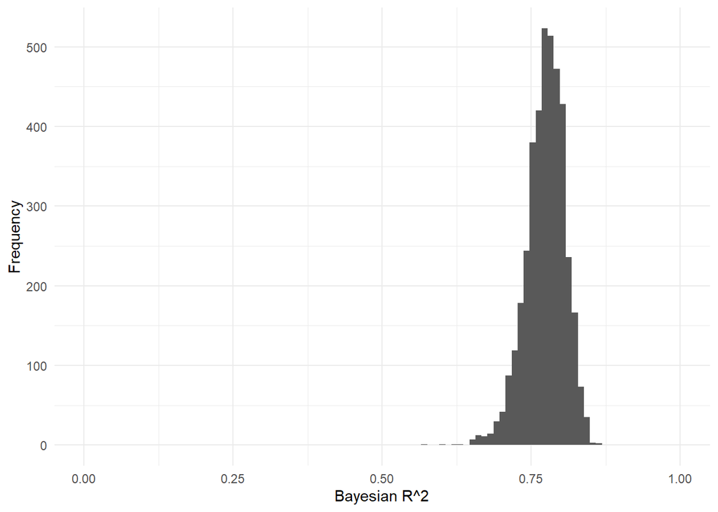

```r
# Step 6: Bayesian R-squared for the reduced model
bayesian_r2_reduced <- bayes_R2(fit_reduced_stan_log)

# Plot posterior distributions of R-squared
ggplot() +
  geom_histogram(aes(x = bayesian_r2_reduced), breaks = seq(0, 1, length.out = 100)) +
  xlim(c(0, 1)) +
  labs(x = "Bayesian R^2", y = "Frequency") +
  theme_minimal()
```

```r
# Step 7: Summarize model performance
summary(fit_reduced_stan_log)
```

```
##
## Model Info:
##  function:     stan_glm
##  family:       gaussian [identity]
##  formula:      log(przrnd) ~ rounds + pctgrn + aveputt
##  algorithm:    sampling
##  sample:       4000 (posterior sample size)
##  priors:       see help('prior_summary')
##  observations: 100
##  predictors:   4
##
## Estimates:
##               mean   sd   10%   50%   90%
## (Intercept)  3.0    1.0  1.8   3.0   4.3
## rounds       0.0    0.0  0.0   0.0   0.0
## pctgrn       0.1    0.0  0.1   0.1   0.1
## aveputt     -0.1    0.0 -0.1  -0.1  -0.1
## sigma        0.5    0.0  0.4   0.5   0.5
##
## Fit Diagnostics:
##            mean   sd   10%   50%   90%
## mean_PPD 7.8    0.1  7.8   7.8   7.9
##
## The mean_ppd is the sample average posterior predictive distribution of the outcome variable (for details see help('summary.stanreg')).
##
## MCMC diagnostics
##               mcse Rhat n_eff
## (Intercept)   0.0  1.0  5258
## rounds        0.0  1.0  2662
## pctgrn        0.0  1.0  3198
## aveputt       0.0  1.0  3351
## sigma         0.0  1.0  4038
## mean_PPD      0.0  1.0  4220
## log-posterior 0.0  1.0  1693
##
## For each parameter, mcse is Monte Carlo standard error, n_eff is a crude measure of effective sample size, and Rhat is the potential scale reduction factor on split chains (at convergence Rhat=1).
```

```r
# Step 8: Posterior predictive intervals for log-transformed response
pred_intervals <- posterior_predict(fit_reduced_stan_log, probs = c(0.05, 0.95))

# View the posterior predictive intervals
head(pred_intervals)
```

```
##             1        2        3        4        5        6        7        8
## [1,] 7.946553 5.555636 8.420101 6.010322 8.789285 6.762555 8.145303 8.064877
## [2,] 6.495768 6.634886 8.870664 6.542855 8.752565 6.795063 7.539341 7.646822
## [3,] 7.439803 6.599520 8.776425 6.891941 9.077526 7.536698 7.671536 8.701264
## [4,] 7.182131 6.350566 9.451327 5.907668 9.244646 8.011513 8.427385 7.904565
## [5,] 7.259140 6.677936 9.023876 6.281955 9.395056 7.262473 7.800769 7.809092
## [6,] 7.732554 6.457040 9.737754 7.810334 8.625270 7.249275 9.024396 8.106859
##             9       10       11       12       13       14       15       16
## [1,] 9.730997 8.320212 7.328361 7.723331 8.215917 7.788439 7.074622 8.866544
## [2,] 9.654108 9.211527 7.414785 6.884640 8.245384 7.116079 6.798957 8.628076
## [3,] 9.333932 8.039965 7.165707 8.296865 8.487364 7.386876 6.264821 8.061260
## [4,] 9.442810 9.164110 7.674012 7.258222 8.538233 6.723653 6.397427 8.537075
## [5,] 9.515324 8.818578 7.850456 8.159454 8.506377 7.755468 5.888130 8.371925
## [6,] 8.886043 9.136701 7.851046 8.176346 8.421913 7.859825 6.452039 8.808756
##            17       18       19       20       21       22       23       24
```

[output cut: 76 more lines]

#Model Interpretation

```r
# Extract summary of posterior distributions for the coefficients
posterior_summary <- summary(fit_reduced_stan_log)
print(posterior_summary)
```

```
##
## Model Info:
##  function:     stan_glm
##  family:       gaussian [identity]
##  formula:      log(przrnd) ~ rounds + pctgrn + aveputt
##  algorithm:    sampling
##  sample:       4000 (posterior sample size)
##  priors:       see help('prior_summary')
##  observations: 100
##  predictors:   4
##
## Estimates:
##               mean   sd   10%   50%   90%
## (Intercept)  3.0    1.0  1.8   3.0   4.3
## rounds       0.0    0.0  0.0   0.0   0.0
## pctgrn       0.1    0.0  0.1   0.1   0.1
## aveputt     -0.1    0.0 -0.1  -0.1  -0.1
## sigma        0.5    0.0  0.4   0.5   0.5
##
## Fit Diagnostics:
##            mean   sd   10%   50%   90%
## mean_PPD 7.8    0.1  7.8   7.8   7.9
##
## The mean_ppd is the sample average posterior predictive distribution of the outcome variable (for details see help('summary.stanreg')).
##
## MCMC diagnostics
##               mcse Rhat n_eff
## (Intercept)   0.0  1.0  5258
## rounds        0.0  1.0  2662
## pctgrn        0.0  1.0  3198
## aveputt       0.0  1.0  3351
## sigma         0.0  1.0  4038
## mean_PPD      0.0  1.0  4220
## log-posterior 0.0  1.0  1693
##
## For each parameter, mcse is Monte Carlo standard error, n_eff is a crude measure of effective sample size, and Rhat is the potential scale reduction factor on split chains (at convergence Rhat=1).
```

```r
posterior_intervals <- posterior_interval(fit_reduced_stan_log, prob = 0.95)
print(posterior_intervals)
```

```
##                    2.5%       97.5%
## (Intercept)  1.00207682  5.02147518
## rounds       0.02114433  0.03365653
## pctgrn       0.06042039  0.12413378
## aveputt     -0.15813601 -0.06730652
## sigma        0.39338316  0.52613678
```

Model Interpretation: The Bayesian model fit for predicting log-transformed prize money per round (log(przrnd)) uses three predictors: rounds, pctgrn (percentage of greens in regulation), and aveputt (average putts per round). Here’s an interpretation of each component of the output: